## Packages and Data

```r
library(tidyverse)
library(here)
# Replace the _____ with the correct file name
df <- read_csv(here('data', 'bike_final(1).csv'))
```

## MODELING: First pair of variables

### Question 1 Identify the explanatory variable

Ans: Temp (Represents the average daily temperature in degrees Fahrenheit)

### Question 2 Identify the response variable

Ans:Count(Number of Bikes rented on a particular day)

### Question 3. Create a linear regression model and display the full output of the model.

```r
m1 <- lm(count ~ temp, data = df)
summary(m1)
```

```
##
## Call:
## lm(formula = count ~ temp, data = df)
##
## Residuals:
##     Min      1Q  Median      3Q     Max
## -4226.6 -1183.9   -47.9  1101.5  3562.4
##
## Coefficients:
##             Estimate Std. Error t value Pr(>|t|)
## (Intercept)  1054.94     203.18   5.192 3.03e-07 ***
## temp           72.58       3.89  18.657  < 2e-16 ***
## ---
## Signif. codes:  0 '***' 0.001 '**' 0.01 '*' 0.05 '.' 0.1 ' ' 1
##
## Residual standard error: 1496 on 498 degrees of freedom
## Multiple R-squared:  0.4114, Adjusted R-squared:  0.4102
## F-statistic: 348.1 on 1 and 498 DF,  p-value: < 2.2e-16
```

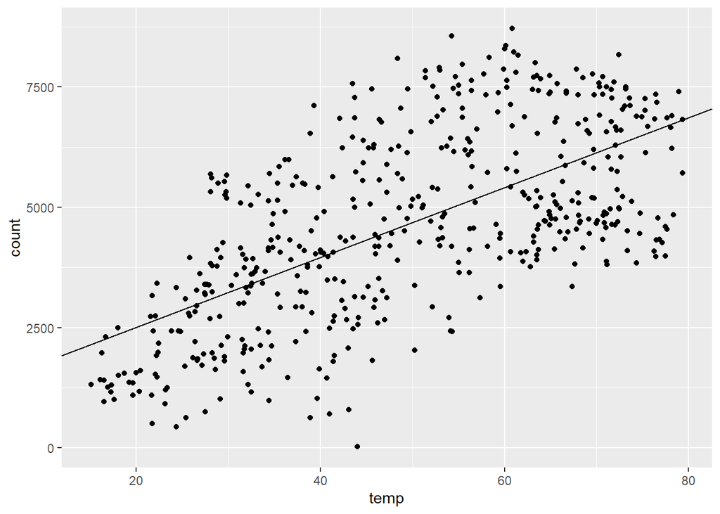

```r
    ggplot(df, aes(x = temp, y =count)) +
    geom_point() +
geom_abline(slope = 72.58, intercept = 1054.94)
```

### Question 4 Using the variables noted in #1 and #2 above and the results of #3, write the equation for your model

Ans: y^= 1054.95 +72.58*temp

### Question 5 Explain what the intercept means in the context of the data.

The number of bikes rented are expected to be around 1054.95 when the average daily temperature is at 0 degree Fahrenheit.

### Question 6 Is the intercept a useful/meaningful value in the context of our data? If yes, explain. If not, explain what purpose it serves.

The intercept of value 1054.95 is of no use in the context of our data. It is because there are no values in the dataset where the average temperature is 0 degree Fahrenheit.

### Question 7 Explain what the slope means in the context of the data.

The value of count of bikes rented increases by an average of 72.58 whenever the value of daily average temperature increases.

## MODELING: Second pair of variables

Count vs Precipitation

### Question 1 Identify the explanatory variable

Ans: • Precipitation(Represents the amount of precipitation, measure in mm)

### Question 2 Identify the response variable

Ans:Count(Number of Bikes rented on a particular day)

### Question 3 Create a linear regression model and display the full output of the model.

```r
m2 <- lm(count ~ precipitation, data = df)
summary(m2)
```

```
##
## Call:
## lm(formula = count ~ precipitation, data = df)
##
## Residuals:
##     Min      1Q  Median      3Q     Max
## -4594.3 -1300.7  -149.9  1282.3  4460.5
##
## Coefficients:
##               Estimate Std. Error t value Pr(>|t|)
## (Intercept)   2698.682    198.288   13.61   <2e-16 ***
## precipitation   42.414      3.988   10.63   <2e-16 ***
## ---
## Signif. codes:  0 '***' 0.001 '**' 0.01 '*' 0.05 '.' 0.1 ' ' 1
##
## Residual standard error: 1760 on 498 degrees of freedom
## Multiple R-squared:  0.1851, Adjusted R-squared:  0.1835
## F-statistic: 113.1 on 1 and 498 DF,  p-value: < 2.2e-16
```

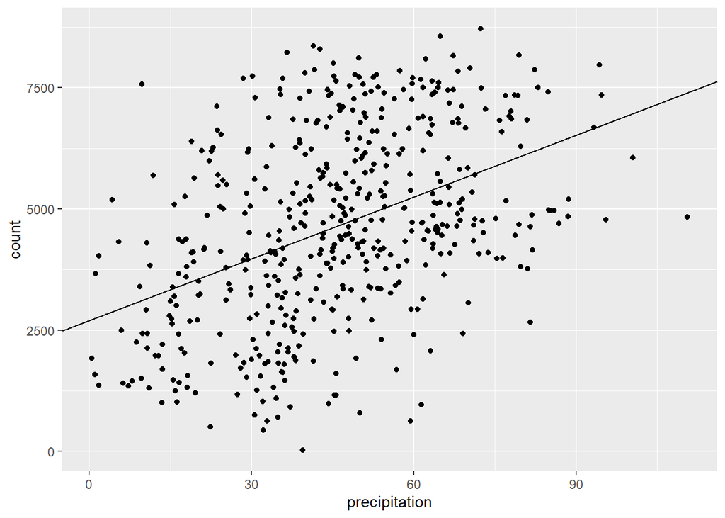

```r
    ggplot(df, aes(x = precipitation, y =count)) +
    geom_point() +
geom_abline(slope = 42.414, intercept = 2698.682)
```

### Question 4 Using the variables noted in #1 and #2 above and the results of #3, write the equation for your model

Ans: y^= 2698.682 +42.414*precipitation

### Question 5 Explain what the intercept means in the context of the data.

The number of bikes rented are expected to be around 2698.682 when the precipitation is 0mm.

### Question 6 Is the intercept a useful/meaningful value in the context of our data? If yes, explain. If not, explain what purpose it serves.

In our dataset, we have a value of 0.433294266 for precipitation. The intercept of value 2698.682 cant be said as not meaningful.

### Question 7 Explain what the slope means in the context of the data.

The value of count of bikes rented increases by an average of 42.414 whenever the value of precipitation increases.

## MODEL ASSESSMENT

### Question 1 Which metric can you use to choose between the two models you just created?

R squared value can be used to find the strength of fit of a linear model.

### Question 2 Explain what this metric means and why it is good for comparing models.

R suared value is computed by taking the square of the correlation coefficient. From the model, it explains the percent of variablility in the Count by the model.

### Question 3 According to this metric, which model is the best of the two you created? Why?

The best of the two is Count vs Temperature model. It is because it has a higher value for R of 0.4114 square than the other two which is having R square value of 0.1851. The best fit for the model is given by the one having the highest R squared value.

## MODEL DIAGNOSTICS

### Question 1 Create two new data columns based on your best model: predicted values for your response variable and the corresponding residuals

```r
mutate_df<-df %>% mutate(Predicted_Values= 1054.94 + 72.58 ∗temp, Residuals = count- Predicted_Values)
mutate_df
```

```
## # A tibble: 500 x 5
##     temp precipitation count Predicted_Values Residuals
##    <dbl>         <dbl> <dbl>            <dbl>     <dbl>
##  1  61           36.6   8227            5482.     2745.
##  2  55           48.2   7538            5047.     2491.
##  3  71.6         67.2   6779            6250.      529.
##  4  63.6         62.7   4549            5670.    -1121.
##  5  39.5          1.75  4035            3922.      113.
##  6  57.3         25.3   3115            5216.    -2101.
##  7  79.3         59.3   5713            6813.    -1100.
##  8  32.5         45.3   1162            3414.    -2252.
##  9  63.2         59.8   7702            5640.     2062.
## 10  39.8         32.5   5409            3940.     1469.
## # ... with 490 more rows
```

### Question 2 Create a plot to check the assumption of linearity. State whether or not this condition is met and explain your reasoning.

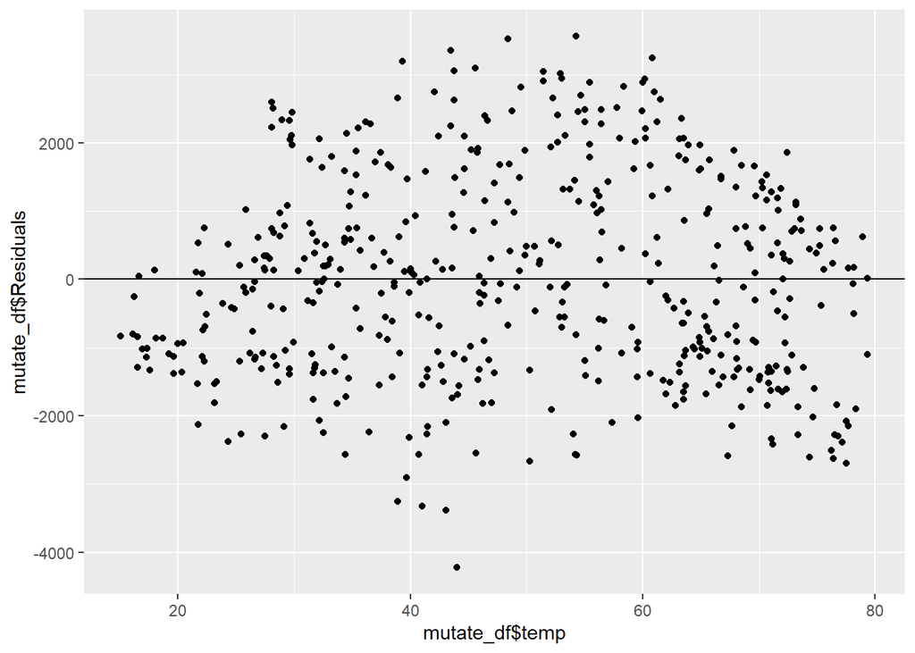

```r
ggplot(mutate_df,aes(x=mutate_df$temp, y=mutate_df$Residuals))+ geom_point()+geom_hline(yintercept=0)
```

From the above graph,we could see some specific pattern,so we could say the condition of linearity is not met.So a linear model is not appropriate to explain the relation between the Count and Daily Average Temperature.

### Question 3 Create a plot to check the assumption of nearly normal residuals. State whether or not this condition is met and explain your reasoning.

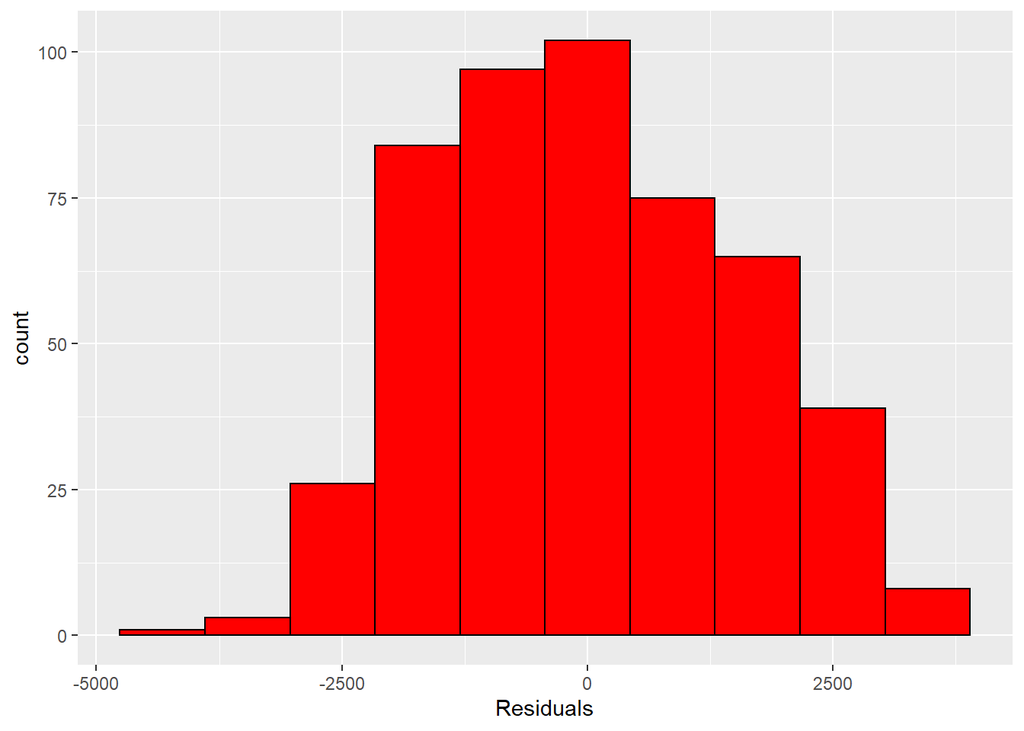

```r
ggplot(mutate_df, aes(x=Residuals)) + geom_histogram(bins=10,colour="black",fill="red")
```

From the above histogram, the residuals appears to be nearly normal.Because the histogram looks like a normal distrubtion having a unimodal,symmertic distribution.

### Question 4 Create a plot to check the assumption of constant variability. State whether or not this condition is met and explain your reasoning.

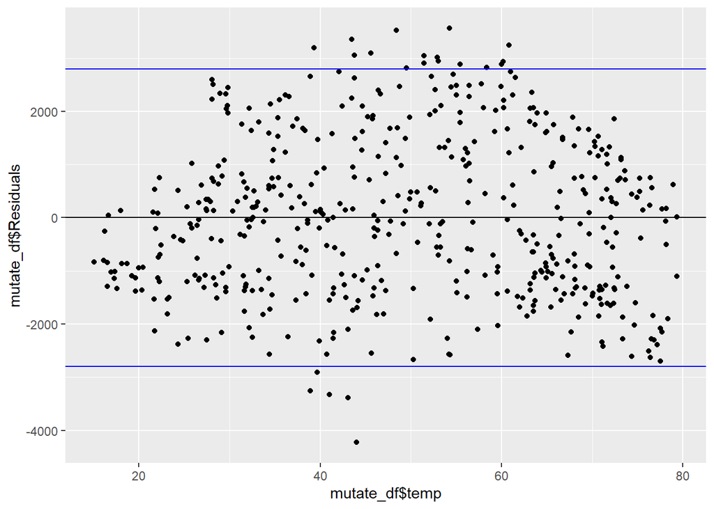

```r
ggplot(mutate_df,aes(x=mutate_df$temp, y=mutate_df$Residuals))+ geom_point()+geom_hline(yintercept=-2800,colour='Blue')+geom_hline(yintercept=2800,colour='Blue')+geom_hline(yintercept=0)
```

Almost all of the data points of Residuals are inside the two blue lines, which are at range of 2800 and -2800,we could say the condition of constant variability has also met.

## CONCLUSION

### Question 1 Based on the results of the “Model Diagnostics” section above, what can you conclude about your model?

Out of all the 3 conditions,the condition of linearity for the least squares is not met. So the relation between Count and Temperature cannot be best predicted best with linear model.